# forest-cover-eda

This is my attempt at some exploratory data analysis on the Forest cover dataset. Also my first public kernel!

```python
# Import libraries
import pandas as pd
import numpy as np
import matplotlib.pyplot as plt
import seaborn as sns
%matplotlib inline
```

```python
filename = '../input/train.csv'
```

```python
# Put the data into a dataframe
df = pd.read_csv(open(filename))
```

**Lets have an overview of the data**

```python
df.describe()
```

|  | Id | Elevation | Aspect | Slope | Horizontal_Distance_To_Hydrology | Vertical_Distance_To_Hydrology | Horizontal_Distance_To_Roadways | Hillshade_9am | Hillshade_Noon | Hillshade_3pm | ... | Soil_Type32 | Soil_Type33 | Soil_Type34 | Soil_Type35 | Soil_Type36 | Soil_Type37 | Soil_Type38 | Soil_Type39 | Soil_Type40 | Cover_Type |
| --- | --- | --- | --- | --- | --- | --- | --- | --- | --- | --- | --- | --- | --- | --- | --- | --- | --- | --- | --- | --- | --- |
| count | 15120.00000 | 15120.000000 | 15120.000000 | 15120.000000 | 15120.000000 | 15120.000000 | 15120.000000 | 15120.000000 | 15120.000000 | 15120.000000 | ... | 15120.000000 | 15120.000000 | 15120.000000 | 15120.000000 | 15120.000000 | 15120.000000 | 15120.000000 | 15120.000000 | 15120.000000 | 15120.000000 |
| mean | 7560.50000 | 2749.322553 | 156.676653 | 16.501587 | 227.195701 | 51.076521 | 1714.023214 | 212.704299 | 218.965608 | 135.091997 | ... | 0.045635 | 0.040741 | 0.001455 | 0.006746 | 0.000661 | 0.002249 | 0.048148 | 0.043452 | 0.030357 | 4.000000 |
| std | 4364.91237 | 417.678187 | 110.085801 | 8.453927 | 210.075296 | 61.239406 | 1325.066358 | 30.561287 | 22.801966 | 45.895189 | ... | 0.208699 | 0.197696 | 0.038118 | 0.081859 | 0.025710 | 0.047368 | 0.214086 | 0.203880 | 0.171574 | 2.000066 |
| min | 1.00000 | 1863.000000 | 0.000000 | 0.000000 | 0.000000 | -146.000000 | 0.000000 | 0.000000 | 99.000000 | 0.000000 | ... | 0.000000 | 0.000000 | 0.000000 | 0.000000 | 0.000000 | 0.000000 | 0.000000 | 0.000000 | 0.000000 | 1.000000 |
| 25% | 3780.75000 | 2376.000000 | 65.000000 | 10.000000 | 67.000000 | 5.000000 | 764.000000 | 196.000000 | 207.000000 | 106.000000 | ... | 0.000000 | 0.000000 | 0.000000 | 0.000000 | 0.000000 | 0.000000 | 0.000000 | 0.000000 | 0.000000 | 2.000000 |
| 50% | 7560.50000 | 2752.000000 | 126.000000 | 15.000000 | 180.000000 | 32.000000 | 1316.000000 | 220.000000 | 223.000000 | 138.000000 | ... | 0.000000 | 0.000000 | 0.000000 | 0.000000 | 0.000000 | 0.000000 | 0.000000 | 0.000000 | 0.000000 | 4.000000 |
| 75% | 11340.25000 | 3104.000000 | 261.000000 | 22.000000 | 330.000000 | 79.000000 | 2270.000000 | 235.000000 | 235.000000 | 167.000000 | ... | 0.000000 | 0.000000 | 0.000000 | 0.000000 | 0.000000 | 0.000000 | 0.000000 | 0.000000 | 0.000000 | 6.000000 |
| max | 15120.00000 | 3849.000000 | 360.000000 | 52.000000 | 1343.000000 | 554.000000 | 6890.000000 | 254.000000 | 254.000000 | 248.000000 | ... | 1.000000 | 1.000000 | 1.000000 | 1.000000 | 1.000000 | 1.000000 | 1.000000 | 1.000000 | 1.000000 | 7.000000 |

8 rows × 56 columns

```python
df.info()
```

```
<class 'pandas.core.frame.DataFrame'>
RangeIndex: 15120 entries, 0 to 15119
Data columns (total 56 columns):
Id                                    15120 non-null int64
Elevation                             15120 non-null int64
Aspect                                15120 non-null int64
Slope                                 15120 non-null int64
Horizontal_Distance_To_Hydrology      15120 non-null int64
Vertical_Distance_To_Hydrology        15120 non-null int64
Horizontal_Distance_To_Roadways       15120 non-null int64
Hillshade_9am                         15120 non-null int64
Hillshade_Noon                        15120 non-null int64
Hillshade_3pm                         15120 non-null int64
Horizontal_Distance_To_Fire_Points    15120 non-null int64
Wilderness_Area1                      15120 non-null int64
Wilderness_Area2                      15120 non-null int64
Wilderness_Area3                      15120 non-null int64
Wilderness_Area4                      15120 non-null int64
Soil_Type1                            15120 non-null int64
Soil_Type2                            15120 non-null int64
Soil_Type3                            15120 non-null int64
Soil_Type4                            15120 non-null int64
Soil_Type5                            15120 non-null int64
Soil_Type6                            15120 non-null int64
Soil_Type7                            15120 non-null int64
Soil_Type8                            15120 non-null int64
Soil_Type9                            15120 non-null int64
Soil_Type10                           15120 non-null int64
Soil_Type11                           15120 non-null int64
Soil_Type12                           15120 non-null int64
Soil_Type13                           15120 non-null int64
Soil_Type14                           15120 non-null int64
Soil_Type15                           15120 non-null int64
Soil_Type16                           15120 non-null int64
Soil_Type17                           15120 non-null int64
Soil_Type18                           15120 non-null int64
Soil_Type19                           15120 non-null int64
Soil_Type20                           15120 non-null int64
Soil_Type21                           15120 non-null int64
Soil_Type22                           15120 non-null int64
Soil_Type23                           15120 non-null int64
Soil_Type24                           15120 non-null int64
Soil_Type25                           15120 non-null int64
Soil_Type26                           15120 non-null int64
Soil_Type27                           15120 non-null int64
Soil_Type28                           15120 non-null int64
Soil_Type29                           15120 non-null int64
Soil_Type30                           15120 non-null int64
Soil_Type31                           15120 non-null int64
Soil_Type32                           15120 non-null int64
Soil_Type33                           15120 non-null int64
Soil_Type34                           15120 non-null int64
Soil_Type35                           15120 non-null int64
Soil_Type36                           15120 non-null int64
Soil_Type37                           15120 non-null int64
Soil_Type38                           15120 non-null int64
Soil_Type39                           15120 non-null int64
Soil_Type40                           15120 non-null int64
Cover_Type                            15120 non-null int64
dtypes: int64(56)
memory usage: 6.5 MB
```

*No missing values!*

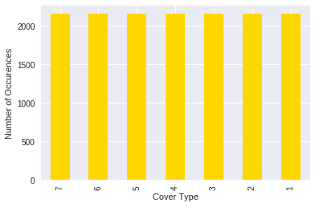

```python
# How many samples of each cover type are there?
df["Cover_Type"].value_counts().plot(kind='bar',color='gold')
plt.ylabel("Number of Occurences")
plt.xlabel("Cover Type")
```

*All cover types have equal representation!*

```python
# Extract column names from the dataset
col_names = df.columns.tolist()
```

Lets see some properties of the continuous variables. We will check out the categorical variables later.

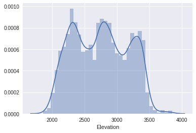

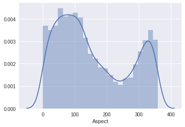

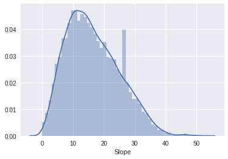

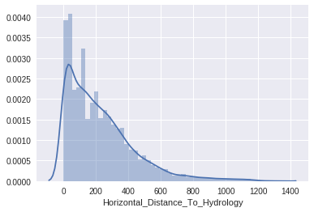

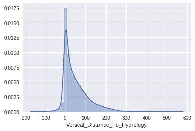

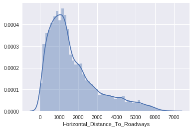

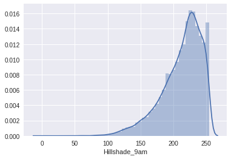

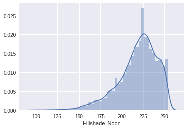

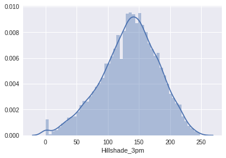

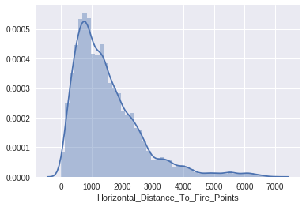

```python
for name in col_names:
    if name[0:4] != 'Soil' and name[0:4] != 'Wild' and name != 'Id' and name != 'Cover_Type':
        plt.figure()
        sns.distplot(df[name]);
```

*Since some variables are left/right skewed, normalization may be useful, going forward.*

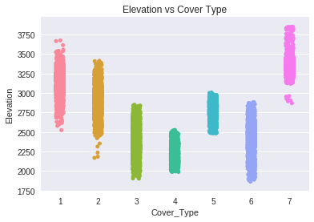

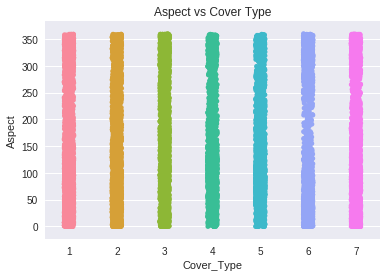

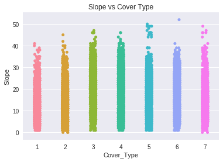

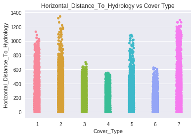

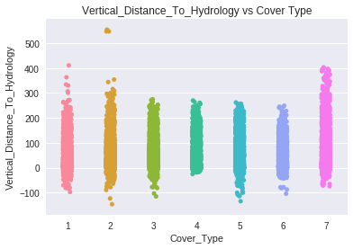

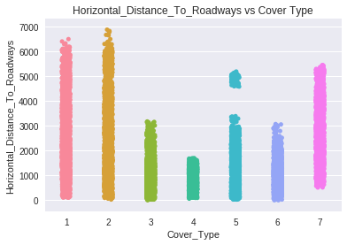

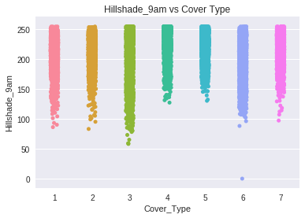

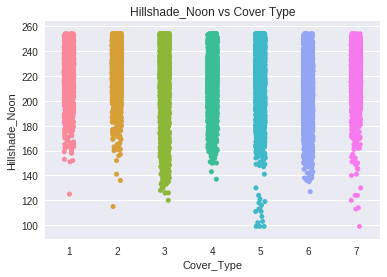

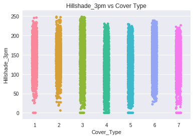

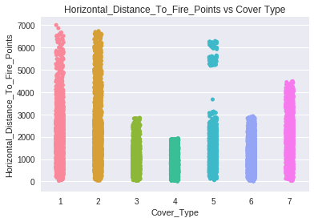

```python
for name in col_names:
    if name[0:4] != 'Soil' and name[0:4] != 'Wild' and name != 'Id' and name != 'Cover_Type':
        title = name + ' vs Cover Type'
        plt.figure()
        sns.stripplot(df["Cover_Type"],df[name],jitter=True)
        plt.title(title);
```

Lets see the correlation between the variables now.

```python
vars = [x for x in df.columns.tolist() if "Soil_Type" not in x]
vars = [x for x in vars if "Wilderness" not in x]
df1 = df.reindex(columns=vars)
```

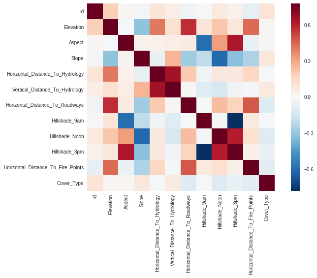

```python
corrmat = df1.corr()
f, ax = plt.subplots(figsize=(12, 7))
sns.heatmap(corrmat, vmax=.5, square=True);
```

*The vertical and horizontal distances to hydrology are strongly correlated.*  
*Hillshade_3pm is highly positively correlated with Hillshade_noon, and highly negatively correlated with Hillshade_9am. It is also positively correlated with aspect.*  
*So we will drop Horizontal_Distance_To_Hydrology and Hillshade_3pm from our analysis.*

```python
drop_cols = ['Horizontal_Distance_To_Hydrology', 'Hillshade_3pm']
df1 = df1.drop(drop_cols, axis=1)
```

Lets see if pairs of variables can give us some discrimination between the cover types. For this analysis, I am excluding Slope and Aspect, since we saw earlier that they were almost similar across cover types.

```python
# So which variables are we plotting?
vars = df1.columns.tolist()
remove_cols = ['Id', 'Slope', 'Aspect', 'Cover_Type']
vars = [x for x in vars if x not in remove_cols]
vars
```

```
['Elevation',
 'Vertical_Distance_To_Hydrology',
 'Horizontal_Distance_To_Roadways',
 'Hillshade_9am',
 'Hillshade_Noon',
 'Horizontal_Distance_To_Fire_Points']
```

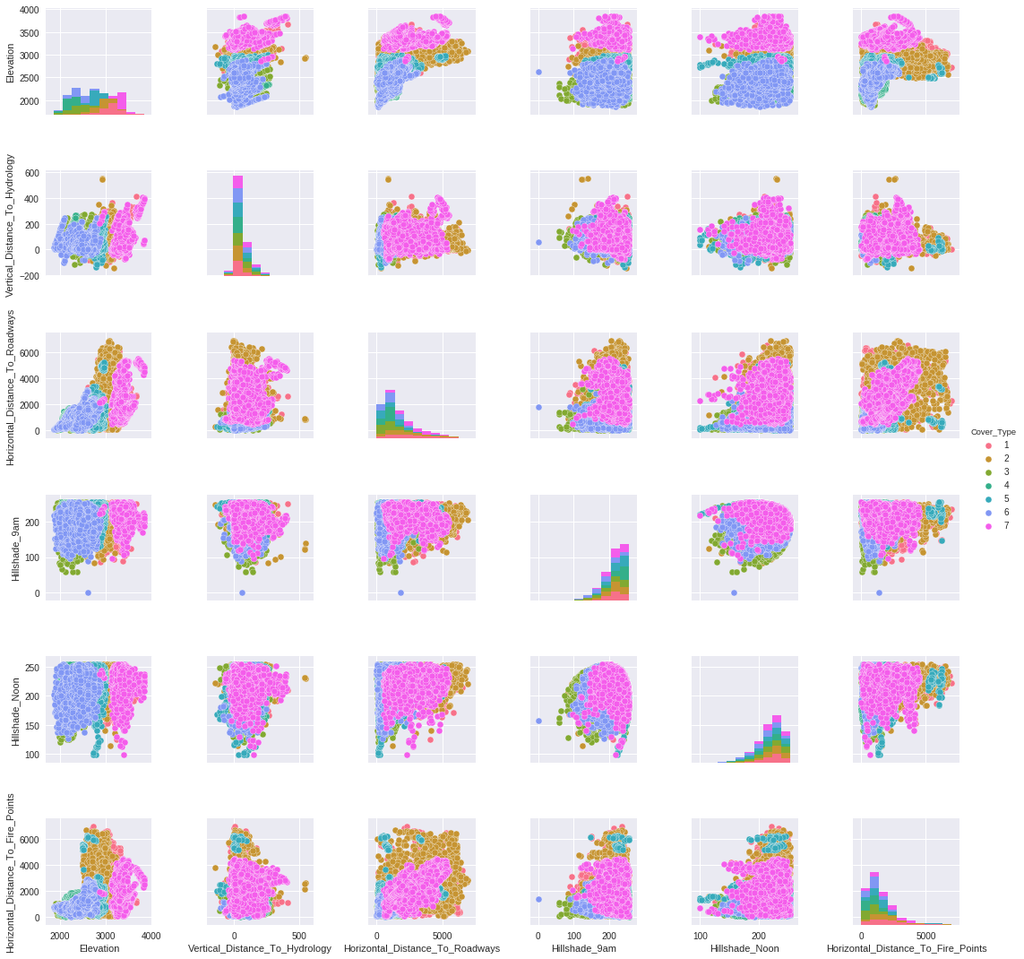

```python
g = sns.pairplot(df, vars=vars, hue="Cover_Type")
```

*I like the ellipse drawn between the two hillshade variables!*

Lets check out the Wilderness variables now..

```python
col_names_wilderness = [x for x in df.columns.tolist() if "Wilderness" in x]
```

```python
types_sum = df[col_names_wilderness].groupby(df['Cover_Type']).sum()
```

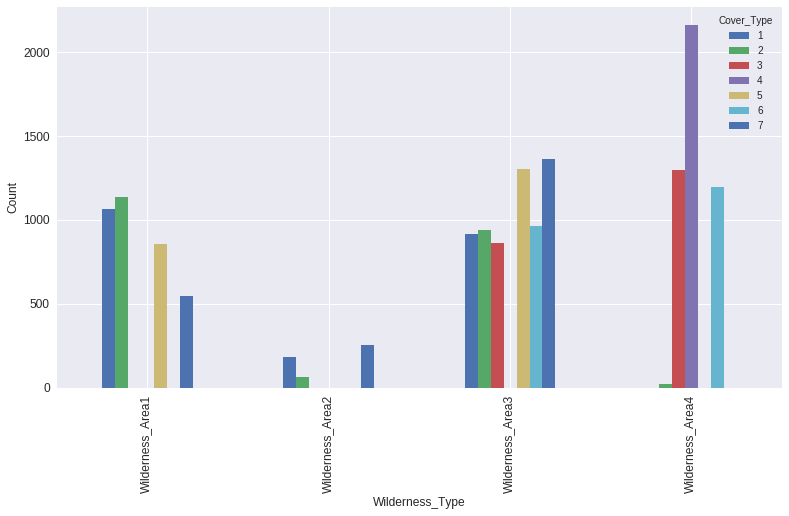

```python
ax = types_sum.T.plot(kind='bar', figsize=(13, 7), legend=True, fontsize=12)
ax.set_xlabel("Wilderness_Type", fontsize=12)
ax.set_ylabel("Count", fontsize=12)
plt.show()
```

*Wilderness_Area2 has very few samples. All of cover_type4 is in Wilderness_Area4, which is excellent.*  
*Distinguishing Cover_Type1 and 2 seems to be very difficult from here.*

Moving on to Soil_Types..

```python
# How many of each Soil_Type are there?
A = np.array(col_names)
soil_types = [item for item in A if "Soil" in item]
for soil_type in soil_types:
    print (soil_type, df[soil_type].sum())
```

```
Soil_Type1 355
Soil_Type2 623
Soil_Type3 962
Soil_Type4 843
Soil_Type5 165
Soil_Type6 650
Soil_Type7 0
Soil_Type8 1
Soil_Type9 10
Soil_Type10 2142
Soil_Type11 406
Soil_Type12 227
Soil_Type13 476
Soil_Type14 169
Soil_Type15 0
Soil_Type16 114
Soil_Type17 612
Soil_Type18 60
Soil_Type19 46
Soil_Type20 139
Soil_Type21 16
Soil_Type22 345
Soil_Type23 757
Soil_Type24 257
Soil_Type25 1
Soil_Type26 54
Soil_Type27 15
Soil_Type28 9
Soil_Type29 1291
Soil_Type30 725
Soil_Type31 332
Soil_Type32 690
Soil_Type33 616
Soil_Type34 22
Soil_Type35 102
Soil_Type36 10
Soil_Type37 34
Soil_Type38 728
Soil_Type39 657
Soil_Type40 459
```

*Seems some soil types are not present at all!*

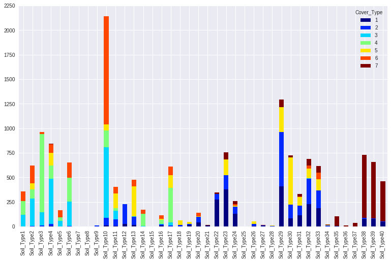

```python
# Which soil_types support which cover_types?
types_sum = df[soil_types].groupby(df['Cover_Type']).sum()
types_sum.T.plot(kind='bar', stacked=True, figsize=(13,8), cmap='jet')
```

Cover_Type7 seems to be present mostly in soil types 35-40.  
Cover_Type6 is found mostly in soil_type10.  
Again, it is difficult to distinguish between Cover_Type1 and 2.

```python
# Lets look at it another way.
arr = []

for i in range(1,8):
    for j in range(1,41):
        result = []
        result.append(i)
        result.append(j)
        mystr = 'Soil_Type' + str(j)
        result.append(df[df['Cover_Type'] == i].sum()[mystr])
        arr.append(result)

labels = ['Cover_Type', 'Soil_Type' , 'Sum']
df1 = pd.DataFrame.from_records(arr, columns=labels)
```

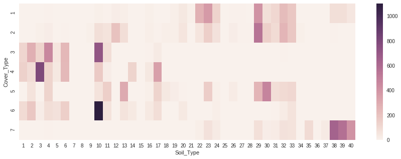

```python
plt.figure(figsize=(15,5))
distt = df1.pivot("Cover_Type", "Soil_Type", "Sum")
ax = sns.heatmap(distt)
```

*I read it left-to-right. This gives the same information as the stacked plot earlier, but from the point of view of cover_types.*

```python
#Lets drop the columns with 0 samples
drop_cols = [item for item in soil_types if df[item].sum() == 0]
drop_cols
```

```
['Soil_Type7', 'Soil_Type15']
```

```python
df = df.drop(drop_cols, axis=1)
```

*Need to make a note of this dropping of columns*!

Please let me know how you liked this analysis. Suggestions for improvement are most welcome! Hopefully I will post some modelling results soon too..